# 6 Opioid Environment Data

## 6.1 Overview

The [Opioid Environment Policy Scan Data Ecosystem](https://oeps.healthyregions.org/), otherwise known as OEPS, is a data resource and warehouse with nationwide health, policy, and community data related to the opioid epidemic, available to download, analyze, and visualize at multiple spatial scales. It integrates social and structural determinants of health, which are grouped thematically. It currently includes hundreds variable constructs with the data available for download as CSV files which can be easily merged with geographic shapefiles (that are also provided).

This tutorial will show you how to access data from OEPS and directly integrate it within your own R environment. Objectives include:

- Navigating the most recent OEPS data suite
- Cleaning, merging, and mapping OEPS data in R
- Integrating additional data to OEPS measures

## 6.2 Environment Setup

To replicate the code and functions illustrated in this tutorial, you will need to have R and RStudio installed on your system. This tutorial assumes some basic familiarity with the R programming language, such as creating objects and running code from an R script.

### 6.2.1 Input/Output

We will download a data package from OEPS directly, and extract data from the `state.csv` file for our analyses, and later merge with geospatial data from the same package, `state-2020-500k-shp`, for mapping and exploration.

We’ll also work with the data at the county level from the same data package, `county.csv` and `county-2020-500k-shp`, and bring in some measures from an external dataset, `NC_cty_foodstamps_2025.csv`.

Our output will be a cleaned county-level CSV file, `final_county_data.csv`, to be used in further research & analyses, as well as several images of maps from our session.

### 6.2.2 Install Libraries

We will use the following packages in this tutorial:

- `tidyverse`: tidy data wrangling tools
- `sf`: to read, manipulate, transform, and write spatial objects
- `tmap`: to create maps

If you have not already installed **tidyverse**, **sf**, and **tmap**, install them first using `install.packages("PackageName")`. Then load them with the `library()` function.

## 6.3 Download OEPS Data

First, go to the [OEPS website](https://oeps.healthyregions.org/).

If this is your first time visiting the site, take a moment to explore the [About OEPS](https://oeps.healthyregions.org/about), [Methodology](https://oeps.healthyregions.org/methods), [Data Inventory](https://oeps.healthyregions.org/docs) and [Data Standards](https://oeps.healthyregions.org/dataInclusion) pages to get familiar with site.

Next, under the *Data Access* tab, click [Download](https://oeps.healthyregions.org/download). On this page, Click *Aggregated Data Packages*.

This tutorial uses data from the 2023 ACS release, which is a 5-year pooled estimate covering 2019-2023.

Under the **DSuite2023** heading, download both of the following files:

- **DSuite2023 data dictionary**
- **DSuite2023 data package (100mb+)**.

See screenshot below.

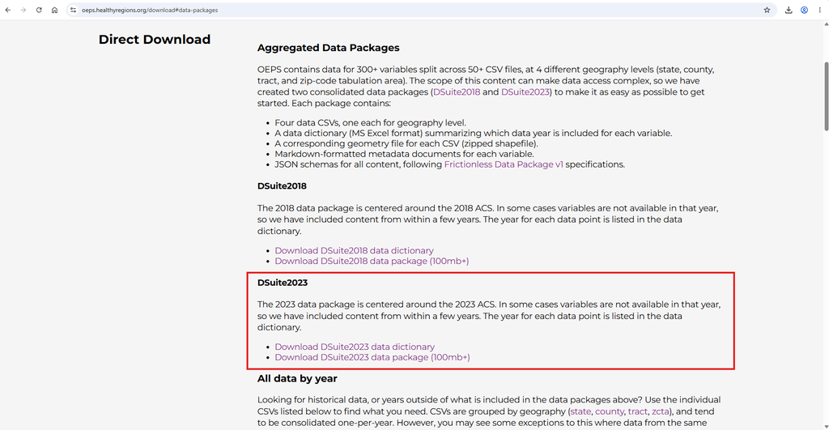

After downloading the files, create a new folder on your computer called **OEPS_Tutorial** and save the files there. If the data package downloads as a .zip file, open your Downloads folder, and extract the contents into your **OEPS_Tutorial** folder before continuing.

We also encourage you to pin this folder to Quick Access.

See the screenshot below.

[figure not shown]

## 6.4 Navigate the Data Suite

Now, that the files have been downloaded, we will take a closer look at the OEPS data suite.

Open **DSuite2023-data-dictionary.xlsx**.

[figure not shown]

The data dictionary explains the contents of the data package including what variables are available at what geography. The columns are:

- **Name:** the exact variable name used in the dataset
- **Title:** the variable label
- **state:** the year for which state-level data are available
- **county:** the year for which county-level data are available
- **tract:** the year for which tract-level data are available
- **zcta:** the year for which ZIP Code Tabulation Area data are available
- **Theme:** the broad thematic group
- **Construct:** the subtopic within each theme
- **Metadata:** a link to the variable metadata, which is also stored in the **metadata** folder

To learn more about each variable, explore the **metadata** folder or navigate to the [**Data Inventory**](https://oeps.healthyregions.org/docs) page on the OEPS website.

## 6.5 Set Up Your R Project

Next, open RStudio and create a new R script called **OEPS_Tutorial_RScript.R**. Save it in your **OEPS_Tutorial** folder.

In the Files pane (usually on the bottom right-hand side), click the three dots on the right side, navigate to your **OEPS_Tutorial** folder, and click **Open**. Then click the gear icon and select **Set As Working Directory**.

If the Files pane is not open, click **View** in the main toolbar and then click **Show Files**.

At this stage, load the libraries referenced at the start of the tutorial.

```r
## Load required packages
library(tidyverse)
library(sf)
library(tmap)
```

## 6.6 Prepare the State-Level Data for Analysis and Visualization

### 6.6.1 Explore the State-Level Dataset

Now, we will read in the state-level CSV file using the `read.csv()` function and inspect its contents.

```r
## Read state.csv
state_data <- read.csv("data/state.csv")

## Glimpse state_data
glimpse(state_data)
```

```
Rows: 56
Columns: 83
$ HEROP_ID     <chr> "040US35", "040US46", "040US06", "040US21", "040US01", "0…
$ FIPS         <int> 35, 46, 6, 21, 1, 13, 5, 42, 29, 8, 49, 40, 47, 56, 36, 1…
$ FqhcAvTmDr   <lgl> NA, NA, NA, NA, NA, NA, NA, NA, NA, NA, NA, NA, NA, NA, N…
$ FqhcCtTmDr   <lgl> NA, NA, NA, NA, NA, NA, NA, NA, NA, NA, NA, NA, NA, NA, N…
$ FqhcTmDrP    <lgl> NA, NA, NA, NA, NA, NA, NA, NA, NA, NA, NA, NA, NA, NA, N…
$ TotTracts    <int> 612, 242, NA, 1376, NA, 2791, NA, 3445, 1654, NA, 716, 29…
$ A50_74HcvD   <int> 92, 10, 1407, 218, 122, 205, 93, 328, 110, 289, 12, 457, …
$ AmInHcvD     <int> NA, 15, 22, NA, NA, NA, NA, NA, NA, 11, NA, 57, NA, NA, N…
$ AsHcvD       <dbl> NA, 0, 87, 0, 0, NA, NA, NA, NA, NA, 0, NA, NA, 0, 17, NA…
$ AvA50_74HcvD <dbl> 131, 6, 1703, 219, 132, 251, 115, 357, 163, 331, 43, 453,…
$ AvAmInHcvD   <dbl> 7, 2, 32, NA, NA, 0, NA, 0, 0, 4, 0, 58, NA, NA, NA, 0, N…
$ AvBlkHcvD    <dbl> NA, NA, 246, 34, 48, 96, 21, 97, 40, 36, NA, 44, 82, 0, 1…
$ AvFlHcvD     <dbl> 40, 0, 605, 88, 46, 84, 42, 114, 60, 112, 20, 163, 139, N…
```

[output cut: 70 more lines]

The state-level dataset contains 56 rows, which represent the 50 states plus the District of Columbia and U.S. territories. It also contains 83 columns, each representing a different variable.

The `glimpse()` function shows the structure of the dataset, including each variable’s type and a preview of its values.

You can also view the loaded dataset by clicking on the name in the **Environment** tab.

### 6.6.2 Choose a Variable to Explore

For this tutorial, we will explore Hepatitis C (HCV) mortality as an example health outcome variable. The same workflow can be used to explore other health outcomes.

Open the **HepatitisC_Rates.md** in the **metadata** folder and read through the contents. The OEPS Hepatitis C (HCV) data was originally sourced from [HepVu](https://hepvu.org/). HepVu includes single-year data from 2018-2022. OEPS researchers cleaned and prepared this data for analysis by aggregating the multiple single year datasets into a single multi-year state-level dataset for 2018-2022.

Hepatitis C, also referred to as HCV, is relevant to opioid-environment research because injection drug use is one of the most common risk factors for HCV infection. People who use drugs are therefore at elevated risk for HCV. HCV can lead to chronic infection, serious liver disease, and/or death if left untreated. For these reasons, HCV is often used as a related health outcome in opioid research.

In the **DSuite2023-data-dictionary.xlsx**, in the **Construct** column, scroll to **Hepatitis C Rates**. You will see several variables related to HCV deaths by age, race, and ethnicity.

For this tutorial, we will use **AvHcvD**, which is the average annual number of HCV deaths from 2018-2022. This variable is only available at the state-level in the OEPS database. While HepVu does include county-level HCV mortality, the data is a calculated estimation. For a complete description of the data, see HepVu’s [Data Methods](https://hepvu.org/data-methods/).

Return to RStudio and locate the **AvHcvD** variable in **state_data**. You will see that the row with FIPS code 35, which corresponds to New Mexico, has an average annual HCV death count of 159 people.

To check which FIPS code corresponds to which state or territory, visit [this page](https://www.census.gov/library/reference/code-lists/ansi/ansi-codes-for-states.html) from the U.S. Census Bureau.

### 6.6.3 Create a Population-Adjusted Measure

Next, we will prepare the data and generate descriptive statistics for the health outcome variable.

The **AvHcvD** variable is a raw count. Because states have different population sizes, we will standardize this measure by dividing **AvHcvD** by **TotPop**, the total population.

We will call this new variable **PropHcvD**. It represents the average annual proportion of the total state population that died from HCV.

Thus, when creating health outcome measures, carefully consider which population belongs in the denominator and clearly justify your choice.

```r
## Create a population-adjusted variable
state_data$PropHcvD <- (state_data$AvHcvD / state_data$TotPop)

## View the first few values
head(state_data$PropHcvD)
```

```
[1] 7.518555e-05 3.669953e-05 5.313079e-05 6.695154e-05 3.185436e-05
[6] 2.698060e-05
```

### 6.6.4 Summarize the Variable

Next, use the `summary()` function to examine the distribution of **PropHcvD**. This output includes the mean, median, minimum, maximum, first quartile, third quartile, and the count of missing values.

```r
## Summarize new variable
summary(state_data$PropHcvD)
```

```
     Min.   1st Qu.    Median      Mean   3rd Qu.      Max.       NAs
1.921e-05 3.190e-05 3.949e-05 4.628e-05 5.381e-05 1.342e-04         5
```

Because these values are very small, they can be difficult to interpret directly. Additionally, the output shows five missing values, which we will address in a later section.

### 6.6.5 Re-express the Variable Per 100,000 People

To make the variable easier to interpret, multiply **PropHcvD** by 100,000. This gives the average annual HCV deaths per 100,000 people. We will call this new variable **AvHcVD100K**.

```r
## Re-express the variable per 100,000 people
state_data$AvHcvD100K <- state_data$PropHcvD * 100000
```

### 6.6.6 Identify Missing Values

Now we will identify the rows with missing values for **AvHcvD100K**. The `is.na` function identifies missing values (labeled as NA) in that variable.

```r
## View the rows with missing AvHcvD100K data
state_data[is.na(state_data$AvHcvD100K),]
```

```
   HEROP_ID FIPS FqhcAvTmDr FqhcCtTmDr FqhcTmDrP TotTracts A50_74HcvD AmInHcvD
30  040US60   60         NA         NA        NA      8706         NA       NA
35  040US72   72         NA         NA        NA       939         NA       NA
48  040US78   78         NA         NA        NA        29         NA       NA
54  040US66   66         NA         NA        NA        56         NA       NA
55  040US69   69         NA         NA        NA        23         NA       NA
   AsHcvD AvA50_74HcvD AvAmInHcvD AvBlkHcvD AvFlHcvD AvHcvD AvHspHcvD AvMlHcvD
30     NA           NA         NA        NA       NA     NA        NA       NA
35     NA           NA         NA        NA       NA     NA        NA       NA
48     NA           NA         NA        NA       NA     NA        NA       NA
54     NA           NA         NA        NA       NA     NA        NA       NA
55     NA           NA         NA        NA       NA     NA        NA       NA
   AvO75HcvD AvU50HcvD MdMarijLaw AnyPdmpDt AnyPdmpFr AnyPdmphDt AnyPdmphFr
30        NA        NA      False                  NA                    NA
35        NA        NA      False                  NA                    NA
```

[output cut: 45 more lines]

These missing values correspond to American Samoa (60), Guam (66), Northern Mariana Islands (69), Puerto Rico (72), and the U.S. Virgin Islands (78). For these locations, the dataset does not include HCV deaths or total population values.

### 6.6.7 Filter the Dataset

For the remainder of this tutorial, we will limit the analysis to the contiguous U.S., which will also make the mapping step easier. This excludes the territories listed above, as well as Alaska (02), and Hawaii (15).

In this step, we are creating a new dataframe object called **state_data_filtered** to store the results. `%>%` is a pipe operator that passes the **state_data** object to the next function. The `filter()` function selects rows from a dataframe based on a logical condition. `%in%` checks whether each numerical value appears in the FIPS column, but `!` reverses the condition and means “not”.

```r
## Filter to the contiguous U.S.
state_data_filtered <- state_data %>% filter(!FIPS %in% c(02, 15, 60, 66, 69, 72, 78))
```

### 6.6.8 Summary Statistics

Now that **AvHcvD100K** has been calculated and processed, use the `summary()` function again to examine the distribution.

```r
## Summarize new variable
summary(state_data_filtered$AvHcvD100K)
```

```
   Min. 1st Qu.  Median    Mean 3rd Qu.    Max.
  1.921   3.194   3.949   4.642   5.313  13.416
```

From this output, we can see the typical range of values across states and identify whether any states have unusually high or low rates. The summary also helps us confirm that the missing values have been removed from the filtered dataset.

The average annual HCV death rate ranges from 1.921 to 13.416 deaths per 100,000 people across states in the contiguous U.S. The median rate is 3.949 and the mean rate is 4.642, which is higher than the median, suggesting that the distribution is slightly right-skewed, with a few states having relatively high rates.

The distribution suggests that HCV mortality is not uniform across states. But it is important to note that summary statistics alone cannot tell us why rates differ. Additional statistical analyses would be needed to examine which factors may account for differences in rates across states.

### 6.6.9 Load the State Shapefile

Now that the data has been prepared, we can create a map of the outcome variable.

Before we can map the data, we need to join the state-level dataset to a state shapefile. The shapefile is included in the OEPS data suite.

In your **OEPS_Tutorial** folder, open the **data** folder and locate **state-2020-500k-shp.zip**. If the file is still compressed, unzip it first. For best organization, create a folder named **state-2020-500k-shp** inside the **data** folder and extract the shapefile contents there.

See the screenshot below.

[figure not shown]

Now load the shapefile into R using the `st_read()` function and display the geometry column using `plot()` to confirm that it imported correctly.

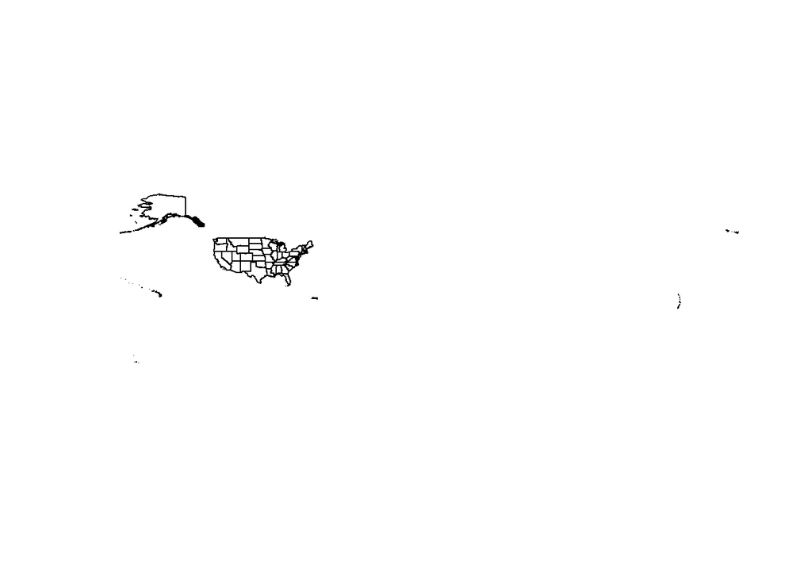

```r
## Load in the state shapefile
state_geom <- st_read("data/state-2020-500k-shp/state-2020-500k.shp")
## Create a quick plot
plot(state_geom$geometry)
```

### 6.6.10 Filter to the Contiguous U.S.

Next, filter the shapefile to include only the contiguous U.S. This excludes Alaska, Hawaii, and the U.S. territories. This coding chunk follows the same logic in the **Filter the Dataset** section.

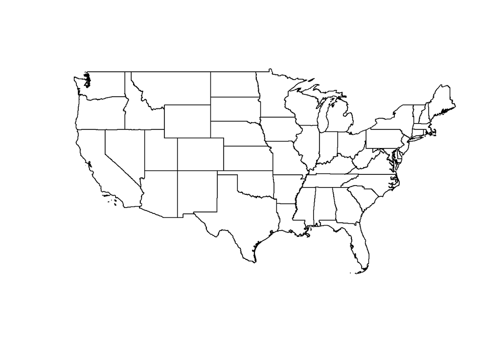

```r
## Filter to the contiguous U.S.
state_geom_filtered <- state_geom %>% filter(!STATEFP %in% c("02", "15", "60", "66", "69", "72", "78"))

## Check plot
plot(state_geom_filtered$geometry)
```

### 6.6.11 Join the Data to the Shapefile

Now join the **state_data_filtered** dataframe to the filtered shapefile. We join using **HEROP_ID** which serves as a unified geographic identifier for joins. To read more about this variable [click here](https://oeps.healthyregions.org/methods). The `left_join()` function combines the two datasets while keeping all rows from the first dataset and adding matching variables from the second dataset.

```r
## Join state_data_filtered to state_geom_filtered
data_to_map <- state_geom_filtered %>%
  left_join(state_data_filtered, by = "HEROP_ID")
```

### 6.6.12 Create a Map

Finally, map **AvHcvD100K**, which represents the average annual HCV death rate per 100,000 people. For more `tmap` resources, [click here](https://r-tmap.github.io/tmap/reference/).

```
[plot mode] fit legend/component: Some legend items or map compoments do not
fit well, and are therefore rescaled.
ℹ Set the tmap option `component.autoscale = FALSE` to disable rescaling.
```

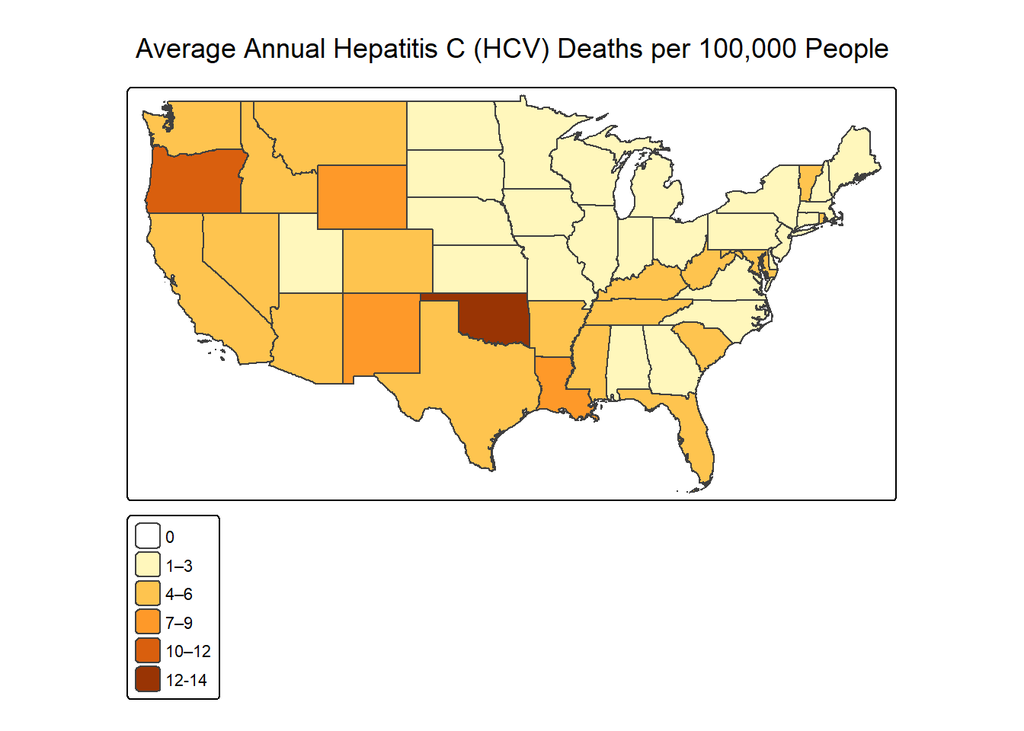

```r
# Map
tm_shape(data_to_map) +
  tm_polygons(
    fill = "AvHcvD100K",
    fill.scale = tm_scale_intervals(
      values = c("white", "#FFF7BC", "#FEC44F", "#FE9929", "#D95F0E", "#993404"),
      breaks = c(0, 0.0000001, 3.99999, 6.99999, 9.99999, 11.99999, 14.99999),
      labels = c("0", "1–3", "4–6", "7–9", "10–12", "12-14"),
      label.na = ""
    ),
    fill.legend = tm_legend(title = "")) +
  tm_title("Average Annual Hepatitis C (HCV) Deaths per 100,000 People")
```

The map suggests that HCV death rates are not evenly distributed across the U.S. Instead, several Southern and Western states appear to have higher rates compared to Northeastern states. Oklahoma appears to have the highest rate of annual HCV deaths.

## 6.7 Prepare the County-Level Data for Analysis and Visualization

OEPS includes data at multiple geographic levels. In this section, we will demonstrate how the state-level workflow can be applied to county-level data. Additionally, we will show how to subset the data to a single state for closer examination.

### 6.7.1 Explore the County-Level Dataset

Now, we will read in the county-level CSV file and inspect its contents.

```r
## Read county.csv
county_data <- read.csv("data/county.csv")

## Glimpse state_data
glimpse(county_data)
```

```
Rows: 3,234
Columns: 100
$ HEROP_ID     <chr> "050US13031", "050US13121", "050US13179", "050US13189", "…
$ FIPS         <int> 13031, 13121, 13179, 13189, 13213, 13209, 13139, 13245, 1…
$ SviSmryRnk   <dbl> 0.8374, 0.6599, 0.9007, 0.6567, 0.6847, 0.7547, 0.8136, 0…
$ SviTh1       <dbl> 0.9297, 0.5571, 0.8167, 0.7353, 0.7852, 0.8858, 0.7897, 0…
$ SviTh2       <dbl> 0.2326, 0.2278, 0.8431, 0.5002, 0.6061, 0.5756, 0.6640, 0…
$ SviTh3       <dbl> 0.7521, 0.9259, 0.9322, 0.8540, 0.5250, 0.7191, 0.7941, 0…
$ SviTh4       <dbl> 0.8781, 0.8501, 0.8600, 0.4076, 0.4909, 0.4518, 0.7416, 0…
$ EssnWrkP     <dbl> 49.9, 27.6, 50.8, 54.9, 54.6, 57.4, 48.3, 53.4, 70.5, 61.…
$ HghRskP      <dbl> 18.0, 10.5, 14.8, 25.2, 41.6, 30.2, 28.9, 18.0, 28.0, 27.…
$ HltCrP       <dbl> 10.1, 10.2, 12.5, 15.5, 8.3, 14.6, 10.0, 16.3, 8.1, 14.0,…
$ RetailP      <dbl> 12.3, 9.0, 14.0, 11.9, 12.0, 9.4, 11.1, 12.3, 12.8, 18.7,…
$ TotWrkE      <int> 36964, 569609, 23579, 9334, 18970, 3565, 99845, 86611, 48…
$ GiniCoeff    <dbl> 0.4849, 0.5296, 0.4089, 0.4515, 0.4337, 0.4652, 0.4493, 0…
```

[output cut: 87 more lines]

The county-level dataset contains 3,234 rows representing individual counties and 100 columns representing different variables.

### 6.7.2 Choose Variables to Explore

Next, we will identify a few variables to explore.

Open **DSuite2023-data-dictionary.xlsx**. Explore the variables that have a year listed under the **county** column. These are variables where data exists at the county-level.

For this tutorial, let’s focus on **PovP**, the number of individuals earning below the poverty income threshold as a percentage of the total population. Open **Economic_Characteristics.md** in the **metadata** folder to read about this variable.

Additionally, let’s look at **FqhcAvTmDr**, the average driving time (minutes) across tracts in state to nearest Federally Qualified Health Center (FQHC). Open **Access_FQHCs.md** in the **metadata** folder to read about this variable.

```r
## Summary statistics for PovP
summary(county_data$PovP)
```

```
   Min. 1st Qu.  Median    Mean 3rd Qu.    Max.     NAs
   1.70   10.00   13.30   14.26   17.50   52.80      99
```

The county-level poverty percentage ranges from 1.7 to 52.8%. The median is 13.3% and the mean is 14.26%, suggesting that the distribution is slightly right-skewed, with few counties having high percentages. There are 99 counties with no percent poverty data.

```r
## Summary statistics for FqhcAvTmDr
summary(county_data$FqhcAvTmDr)
```

```
   Min. 1st Qu.  Median    Mean 3rd Qu.    Max.     NAs
   0.00    8.52   14.13   20.85   27.55   89.82     168
```

The county-level average driving time to nearest FQHC ranges from 0 to 89.82 minutes. The median is 14.13 minutes and the mean is 20.85 minutes, which suggests that most counties are relatively close to an FQHC, but some are much further away. There are 168 counties with missing data, which corresponds to the worst access, where travel takes over 90 minutes in optimal conditions, or 180 minutes in normal conditions.

### 6.7.3 Filter the Dataset to a Single State

Next, we filter the county dataset to just counties in a single state using the **HEROP_ID** variable. In this tutorial, we will zoom in on North Carolina.

The **HEROP_ID** consists of four parts:

- The 3-digit summary level code for counties: 050
- The string: US
- The 2-digit state FIPS code
- The 3-digit county FIPS code

In the following code, we filter by the 6th and 7th positions of the HEROP_ID string which correspond to the 2-digit state FIPS code. North Carolina’s FIPS code is 37.

To check which FIPS code corresponds to which state or territory, visit [this page](https://www.census.gov/library/reference/code-lists/ansi/ansi-codes-for-states.html) from the U.S. Census Bureau.

```r
## Filter to a single state
county_data_filtered <- county_data %>%
  filter(substr(HEROP_ID, 6, 7) %in% c("37"))

## View the first few values
head(county_data_filtered)
```

```
    HEROP_ID  FIPS SviSmryRnk SviTh1 SviTh2 SviTh3 SviTh4 EssnWrkP HghRskP
1 050US37083 37083     0.9870 0.9844 0.9007 0.9332 0.9360     57.3    25.9
2 050US37179 37179     0.2008 0.2221 0.3786 0.6701 0.0932     38.5    22.6
3 050US37129 37129     0.4289 0.5638 0.0824 0.5797 0.4989     40.5    15.5
4 050US37163 37163     0.9459 0.9300 0.8702 0.8721 0.8670     56.8    32.9
5 050US37031 37031     0.3888 0.4547 0.2558 0.4057 0.4432     46.8    16.7
6 050US37183 37183     0.3621 0.2526 0.3229 0.7989 0.4257     30.8    16.1
  HltCrP RetailP TotWrkE GiniCoeff MedInc  PciE PovP UnempP LngTermP MobileP
1   15.7    10.6   18108    0.4891  37991 26951 25.2    8.7     26.8    24.7
2   10.8    11.7  123262    0.4455  51241 45355  7.7    4.2     13.1     4.8
3   14.2    11.7  119132    0.4801  44816 46083 12.4    4.7     11.7     2.7
4   15.6    13.0   24859    0.4520  37968 26978 20.2    5.2     25.4    34.0
5   12.1    13.1   30470    0.4628  41628 42707 10.0    4.3     18.3    16.8
6   11.8     9.3  611492    0.4486  58520 52949  7.9    4.2     10.6     2.7
  RentalP TotUnits UnitDens VacantP FqhcAvTmDr FqhcCtTmDr FqhcTmDrP TotTracts
```

[output cut: 62 more lines]

### 6.7.4 Load the County Shapefile

Before we can map the data, we need to join the filtered dataset to a county shapefile. The shapefile is included in the OEPS data suite.

In your **OEPS_Tutorial** folder, open the data folder and locate **county-2020-500k-shp.zip**. If the file is still compressed, unzip it first. For best organization, create a folder named **county-2020-500k-shp** inside the **data** folder and extract the shapefile contents there.

Now, load the shapefile into R and display the geometry column to confirm that it imported correctly.

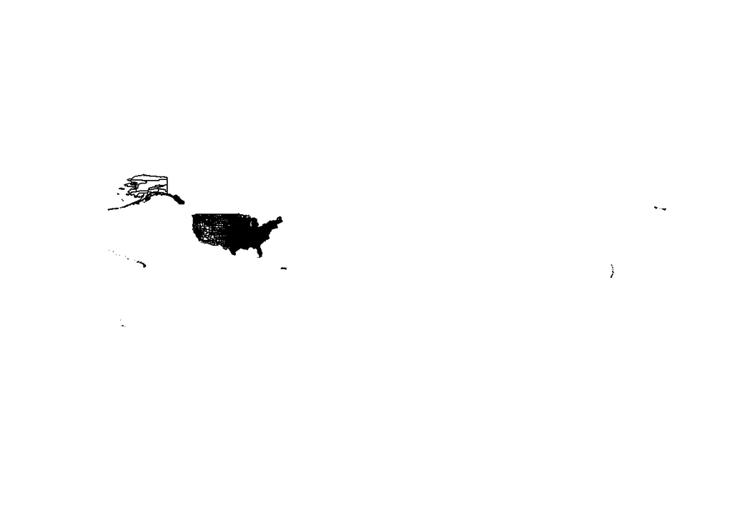

```r
## Load in the county shapefile
county_geom <- st_read("data/county-2020-500k-shp/county-2020-500k.shp")
## Create a quick plot
plot(county_geom$geometry)
```

### 6.7.5 Filter Shapefile to a Single State

Next, filter the shapefile to only include North Carolina counties.

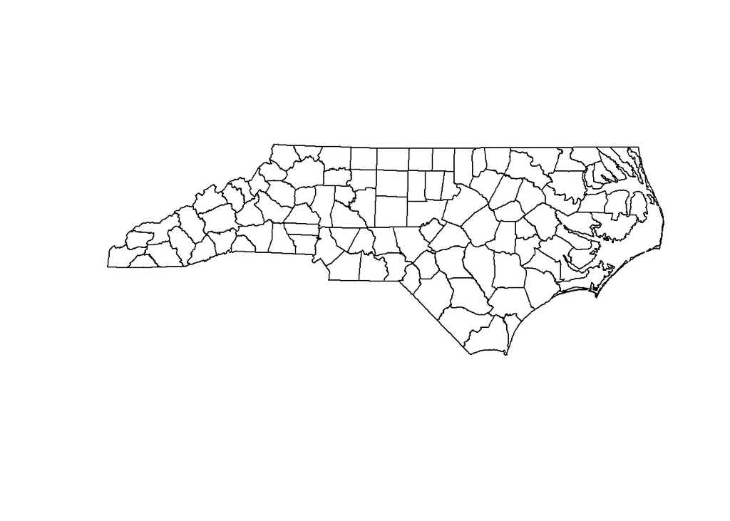

```r
## Filter to a single state
county_geom_filtered <- county_geom %>% filter(STATEFP %in% c("37"))

## Check plot
plot(county_geom_filtered$geometry)
```

### 6.7.6 Join the Data to the Shapefile

Now join the **county_data_filtered** dataframe to the filtered shapefile.

```r
## Join county_data_filtered to county_geom_filtered
data_to_map_county <- county_geom_filtered %>%
  left_join(county_data_filtered, by = "HEROP_ID")
```

### 6.7.7 Create Maps

Finally, map **PovP**, the number of individuals earning below the poverty income threshold as a percentage of the total population and **FqhcAvTmDr**, the average driving time (minutes) across tracts in state to nearest Federally Qualified Health Center (FQHC).

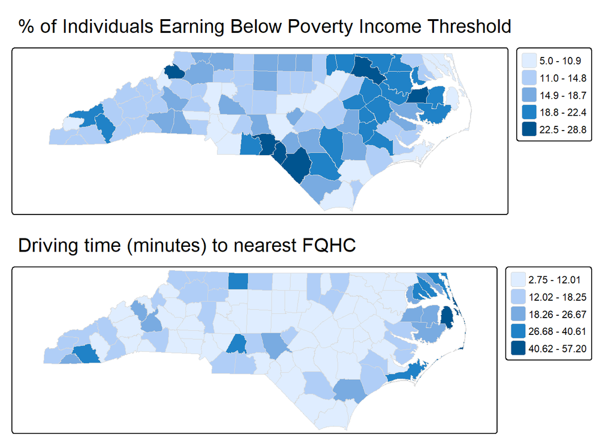

```r
## Map PovP
PovP <- tm_shape(data_to_map_county) +
  tm_polygons(
    fill = "PovP",
    fill.scale = tm_scale_intervals(style = "jenks"),
    fill.legend = tm_legend(title = ""),
    col = "grey85",
    lwd = 0.2) +
  tm_title("% of Individuals Earning Below Poverty Income Threshold")

## Map FqhcAvTmDr
FqhcAvTmDr <- tm_shape(data_to_map_county) +
  tm_polygons(
    fill = "FqhcAvTmDr",
    fill.scale = tm_scale_intervals(style = "jenks"),
    fill.legend = tm_legend(title = ""),
    col = "grey85",
    lwd = 0.2) +
  tm_title("Driving time (minutes) to nearest FQHC")

## Arrange the maps
tmap_arrange(PovP, FqhcAvTmDr)
```

The **PovP** map shows us that poverty is unevenly distributed across the state. Poverty percentages appear higher in several Eastern and Southern counties, whereas many counties in the central Piedmont have lower poverty rates.

For the **FqhcAvTmDr** map, most counties appear to have relatively short driving times, especially in the central part of the state. Longer travel times seem more common in some coastal and mountain areas, where access may be more limited. There are no counties that exceed a driving time of 58 minutes.

## 6.8 Join OEPS data to additional data

Sometimes users will already have their own data and want to add OEPS variables for context. In this section, we will demonstrate how to join OEPS county-level data to an outside dataset using a shared geographic identifier.

The **NC_cty_foodstamps_2025.csv** contains information about the county-level prevalence of food stamps in North Carolina for 2025, which was originally pulled from [CDC’s PLACES](https://www.cdc.gov/places/index.html) dataset.

```r
## Read in non-OEPS data
foodstamps_data <- read.csv("data/NC_cty_foodstamps_2025.csv")

## Glimpse foodstamps_data
glimpse(foodstamps_data)
```

```
Rows: 100
Columns: 11
$ StateAbbr           <chr> "NC", "NC", "NC", "NC", "NC", "NC", "NC", "NC", "N…
$ StateDesc           <chr> "North Carolina", "North Carolina", "North Carolin…
$ CountyName          <chr> "Bertie", "Vance", "New Hanover", "Martin", "Edgec…
$ StateFIPS           <int> 37, 37, 37, 37, 37, 37, 37, 37, 37, 37, 37, 37, 37…
$ CountyFIPS          <int> 15, 181, 129, 117, 65, 95, 159, 55, 193, 125, 45, …
$ TotalPopulation     <chr> "16,922", "42,301", "238,852", "21,447", "48,832",…
$ TotalPop18plus      <chr> "14,112", "32,113", "197,058", "17,125", "37,653",…
$ FOODSTAMP_CrudePrev <dbl> 24.9, 22.9, 9.0, 19.9, 24.8, 19.9, 14.1, 6.4, 13.6…
$ FOODSTAMP_Crude95ci <chr> "(20.8, 29.1)", "(18.8, 26.9)", "( 6.8, 11.6)", "(…
$ FOODSTAMP_AdjPrev   <dbl> 26.7, 24.2, 9.6, 21.6, 26.3, 20.8, 14.8, 7.0, 14.7…
$ FOODSTAMP_Adj95CI   <chr> "(22.1, 31.3)", "(19.9, 28.7)", "( 7.3, 12.5)", "(…
```

Often times, datasets will have a **FIPS** or **GEOID** column that can be used for joining to other datasets. Sometimes, these columns will not be the same format, in which case, joining will not work. Thus, you will need to re-format the columns before joining.

In **foodstamps_data**, we have a column called **StateFIPS** which stores the 2-digit state FIPS code and a **CountyFIPS** column which stores the 3-digit county FIPS code. However, CSV files often delete leading zeros, which is why you see some 1- or 2-digit values in **CountyFIPS**.

Let’s check again to see what identifier columns are in **county_data_filtered**.

```r
## Glimpse county_data_filtered
glimpse(county_data_filtered)
```

```
Rows: 100
Columns: 100
$ HEROP_ID     <chr> "050US37083", "050US37179", "050US37129", "050US37163", "…
$ FIPS         <int> 37083, 37179, 37129, 37163, 37031, 37183, 37119, 37087, 3…
$ SviSmryRnk   <dbl> 0.9870, 0.2008, 0.4289, 0.9459, 0.3888, 0.3621, 0.6115, 0…
$ SviTh1       <dbl> 0.9844, 0.2221, 0.5638, 0.9300, 0.4547, 0.2526, 0.5787, 0…
$ SviTh2       <dbl> 0.9007, 0.3786, 0.0824, 0.8702, 0.2558, 0.3229, 0.4747, 0…
$ SviTh3       <dbl> 0.9332, 0.6701, 0.5797, 0.8721, 0.4057, 0.7989, 0.8915, 0…
$ SviTh4       <dbl> 0.9360, 0.0932, 0.4989, 0.8670, 0.4432, 0.4257, 0.5135, 0…
$ EssnWrkP     <dbl> 57.3, 38.5, 40.5, 56.8, 46.8, 30.8, 35.7, 49.7, 50.1, 46.…
$ HghRskP      <dbl> 25.9, 22.6, 15.5, 32.9, 16.7, 16.1, 16.3, 21.2, 24.6, 19.…
$ HltCrP       <dbl> 15.7, 10.8, 14.2, 15.6, 12.1, 11.8, 11.5, 15.1, 12.3, 16.…
$ RetailP      <dbl> 10.6, 11.7, 11.7, 13.0, 13.1, 9.3, 10.3, 11.1, 12.6, 11.7…
$ TotWrkE      <int> 18108, 123262, 119132, 24859, 30470, 611492, 616325, 2827…
$ GiniCoeff    <dbl> 0.4891, 0.4455, 0.4801, 0.4520, 0.4628, 0.4486, 0.4935, 0…
```

[output cut: 87 more lines]

In **county_data_filtered**, we have **HEROP_ID**, our unique OEPS identifier and **FIPS** which stores the 5-digit combined state and county FIPS codes.

It is obvious that the two datasets we want to join do not have a shared geographic identifier. But, we have all the information we need to create one!

Let’s keep the OEPS data as is, and instead alter **foodstamps_data** by creating a 5-digit FIPS column. To do so, we need to combine **StateFIPS** with **CountyFIPS** ensuring that **CountyFIPS** does not leave out leading zeros. Here we use the `mutate()` function to create a new variable called **FIPS**. `sprintf` combines the state and county FIPS codes into a 5-digit code:

- `%02d` formats the state code as a 2-digit integer, adding leading zeros when necessary
- `%03d` formats the county code as a 3-digit integer, adding leading zeros when necessary

The `as.numeric()` function converts the 5-digit code into a numeric value.

```r
## Create a FIPS column
foodstamps_data <- foodstamps_data %>%
  mutate(FIPS = as.numeric(sprintf("%02d%03d", StateFIPS, CountyFIPS)))

## View the first few values
head(foodstamps_data)
```

```
  StateAbbr      StateDesc  CountyName StateFIPS CountyFIPS TotalPopulation
1        NC North Carolina      Bertie        37         15          16,922
2        NC North Carolina       Vance        37        181          42,301
3        NC North Carolina New Hanover        37        129         238,852
4        NC North Carolina      Martin        37        117          21,447
5        NC North Carolina   Edgecombe        37         65          48,832
6        NC North Carolina        Hyde        37         95           4,607
  TotalPop18plus FOODSTAMP_CrudePrev FOODSTAMP_Crude95ci FOODSTAMP_AdjPrev
1         14,112                24.9        (20.8, 29.1)              26.7
2         32,113                22.9        (18.8, 26.9)              24.2
3        197,058                 9.0        ( 6.8, 11.6)               9.6
4         17,125                19.9        (16.4, 23.7)              21.6
5         37,653                24.8        (20.5, 29.3)              26.3
6          3,922                19.9        (16.6, 23.3)              20.8
  FOODSTAMP_Adj95CI  FIPS
1      (22.1, 31.3) 37015
2      (19.9, 28.7) 37181
3      ( 7.3, 12.5) 37129
4      (17.9, 25.8) 37117
5      (21.8, 31.1) 37065
6      (17.4, 24.7) 37095
```

Now we have a shared geographic identifier, **FIPS**, and can join the two datasets.

```r
## Join foodstamps_data to county_data_filtered
final_county_data <- county_data_filtered %>%
  left_join(foodstamps_data, by = "FIPS")

## Glimpse final_county_data
glimpse(final_county_data)
```

```
Rows: 100
Columns: 111
$ HEROP_ID            <chr> "050US37083", "050US37179", "050US37129", "050US37…
$ FIPS                <dbl> 37083, 37179, 37129, 37163, 37031, 37183, 37119, 3…
$ SviSmryRnk          <dbl> 0.9870, 0.2008, 0.4289, 0.9459, 0.3888, 0.3621, 0.…
$ SviTh1              <dbl> 0.9844, 0.2221, 0.5638, 0.9300, 0.4547, 0.2526, 0.…
$ SviTh2              <dbl> 0.9007, 0.3786, 0.0824, 0.8702, 0.2558, 0.3229, 0.…
$ SviTh3              <dbl> 0.9332, 0.6701, 0.5797, 0.8721, 0.4057, 0.7989, 0.…
$ SviTh4              <dbl> 0.9360, 0.0932, 0.4989, 0.8670, 0.4432, 0.4257, 0.…
$ EssnWrkP            <dbl> 57.3, 38.5, 40.5, 56.8, 46.8, 30.8, 35.7, 49.7, 50…
$ HghRskP             <dbl> 25.9, 22.6, 15.5, 32.9, 16.7, 16.1, 16.3, 21.2, 24…
$ HltCrP              <dbl> 15.7, 10.8, 14.2, 15.6, 12.1, 11.8, 11.5, 15.1, 12…
$ RetailP             <dbl> 10.6, 11.7, 11.7, 13.0, 13.1, 9.3, 10.3, 11.1, 12.…
$ TotWrkE             <int> 18108, 123262, 119132, 24859, 30470, 611492, 61632…
$ GiniCoeff           <dbl> 0.4891, 0.4455, 0.4801, 0.4520, 0.4628, 0.4486, 0.…
```

[output cut: 98 more lines]

From here, you could use this dataset for further analysis and visualization.

## 6.9 Save Outputs

Finally, let’s save our outputs. We will save the final joined county dataset as a CSV, and the county-level maps as images.

```r
## Save final_county_data
write.csv(final_county_data, "final_county_data.csv")

## Save county-level maps
tmap_save(PovP, filename = "PovP_map.png")
tmap_save(FqhcAvTmDr, filename = "FqhcAvTmDr_map.png")
```

## 6.10 More Resources

[Click here](https://oeps.healthyregions.org/) to learn more about the OEPS ecosystem.

Visit the [Geospatial Consortium & Community of Practice website](https://gccp.healthyregions.org/) to learn about past and upcoming workshops.

For more on the tmap package [click here](https://r-tmap.github.io/tmap/reference/).